# 琅琊榜小说文本案例分析

狗熊会

案例难度：***

案例背景：根据海晏同名小说改编的架空权谋类电视剧《琅琊榜》首登荧屏便获得收视佳绩。如此优秀的电视剧，其小说原著必然也是精彩绝伦。本案例试图借助文本分析的方法，从人物、故事情节和环境三要素入手，探索琅琊榜小说中关于小说三要素的蛛丝马迹。 案例原文详见[从文本分析看小说三要素：以琅琊榜为例](http://mp.weixin.qq.com/s/gNyPhi3FtJOsxU8KJvk9hw)

本案例的目标：学习处理文本数据。

## 准备工作

```r
# 清除工作环境
cat("\014");rm(list=ls())
```

## 任务一

读入《琅琊榜》小说文本，提取出人物对话的段落，并展示数据前5行。提示：这里采取冒号出现的地方定位人物对话的段落。

```
## [1] "　　曾有人很奇怪地问过琅琊阁主：“你不可能真的什么都知道，如果有人来问皇帝陛下有几根头发，或者伏灵圣女昨晚睡觉时梦见了谁，你怎么回答？”"
## [2] "　　琅琊阁主邪恶地一笑道：“因为所有问题都由我定价。比如刚才那两个问题，我就定价三千万两银子。谁肯付这么一大笔钱，只为了砸我的招牌玩玩？人们真正花钱要知道的事情，多半都是可以调查出来的事情，至少我目前为止，还没遇上象你这么无聊的人。”"
## [3] "　　那人撇撇嘴失望地道：“咦，你原来是个骗子。”"
## [4] "　　皇帝抱着婴儿看了半天，虽无决断，但因心中十分喜爱，便想出了一个折中之计：“既然无法确认这孩子究竟是何人之子，那他姓谢姓卓都不合适，朕就赐国姓于他，按皇子辈取名，叫景……景睿好了，他生在睿山之上嘛。一年住在谢家，下一年就住在卓家，算是两姓之子，如何？”"
## [5] "　　当然，只要一入琅琊榜，再默默无闻的人也会一朝名闻天下知，成为众人追捧的对象。何况这种美人儿多半都是琼闺秀玉，身份不低，所以求亲的、说媒的、重金只求一睹芳容的，几乎要踏破门槛儿。这些熙熙攘攘的爱慕者中只有少数有运气能亲眼看到美人玉颜，然后留下几句迷迷晕晕的评论：“美，真是太美了，果然不愧是琅琊美人……”"
```

## 任务二

本任务对特定人物进行分析。以“梅长苏”为例。对包含“梅长苏”的段落进行分词，并按照词频降序保存词频及对应词性，用head函数显示前几名词频及其词性。提示：为了做个示例，我们将包含梅长苏和宗主的段落都看成是包含梅长苏的段落。

完成此任务需要对中文文本分词有基本的认识。下面做简要介绍

进行初步的分词尝试，加载jiebaR分词包，通过cutter来设置分词环境。

提示：本任务有四个关键点，

1、学习进行逐行分词；

2、学习添加自定义词典,jieba提供的是一个通用的词根库，因此对于琅琊榜里的一些词语比如梅长苏、琅琊阁这样的是分不出来的，如果要进行分词该怎么办呢？就要向词根库里添加这些自定义词根，即需要有一个自定义词典，大家想想哪里有这样现成的词典？搜狗细胞词库是一个特别好的东东，但是唯一的缺点就是需要把它转成txt，老师只能帮你到这了。

3、学习去掉停用词，语言中使用的功能词（语气助词、副词、介词、连接词），这些功能词通常极其普遍，并没有什么实际含义，比如：“你、我、他、了、的”，在分词的时候最好把这些停用词去掉，可以优化分词结果，很多机构都给出了自己的停用词表，如“百度”，“哈工大”，“四川大学机器自然实验室”等。我们给出了一个汇总的停用词表供大家使用。

4、学习对分词结果进行词性标注

```
##      text_all2 Freq tag_all2
## 1           　 1538        x
## 2600    梅长苏  771        n
## 3728        说  145        v
## 911       殿下  117        n
## 1144      飞流  109        n
## 2038      靖王   87        n
```

## 任务三

对地点进行分析。读入主要地点txt数据文件，统计“金陵”,“地道”,“悬镜司”,“苏宅”,“天牢”,“琅琊阁”,“靖王府”7个地点在小说中的出现频数，并绘制柱形图。

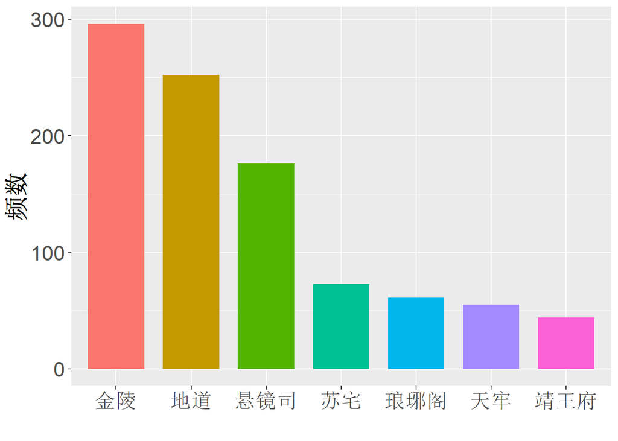

## 任务四

对剧情进行分析。以“第一卷”为例。对小说第一卷内容进行分词。按照词频降序保存名词词根，并进一步筛选出长度大于等于2的词根。用head函数显示前几行名词词根。

```
##      text_all Freq
## 3737   梅长苏  497
## 6494   萧景睿  412
## 6585     谢弼  223
## 6831   言豫津  211
## 1630     飞流  191
## 5558     苏兄  135
```

## 任务五

统计主要人物在全书的出场频次并绘制柱形图。

提示：这里需要注意的是对于某一个人物可能要统计他不同称谓， 例如梅长苏就有好几种叫法，比如苏哲、小殊、林殊等等说法。

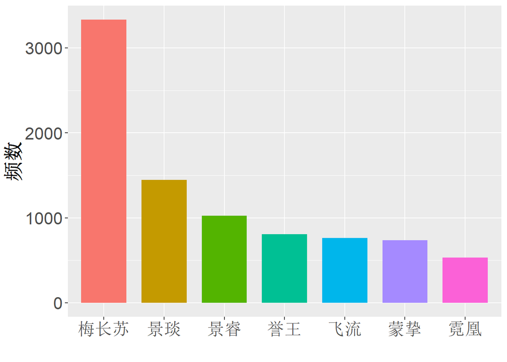